# Notes, September 12:Simple Regression

```r
load("/Users/isabellelangrock/Desktop/Stats500/Rst500.RData")
library(ltm)
library(car)
```

# Thursday, September 12

## Simple Regression

- Points of Predictions
- Checking the Model
  - residuals vs. fitted
  - normal plot of residuals
- Regression ANOVA
- Correlation

## **Useful R Functions**

- lm()
- qqnorm()
- qqline()
- boxplot()
- plot()

```r
attach(fuel)
m<-lm(Fuel~Tax)
predict(m,data.frame(Tax=8.5), interval="confidence")
```

```
##        fit      lwr      upr
## 1 532.6041 493.4677 571.7405
```

```r
predict(m, data.frame(Tax=8.5), interval="predict")
```

```
##        fit      lwr      upr
## 1 532.6041 325.7185 739.4897
```

```r
data.frame(state, Tax, Fuel, predict(m, data.frame(Tax=Tax, interval="predict")))
```

```
##    state   Tax Fuel
## 1     ME  9.00  541
## 2     NH  9.00  524
## 3     VT  9.00  561
## 4     MA  7.50  414
## 5     RI  8.00  410
## 6     CN 10.00  457
## 7     NY  8.00  344
## 8     NJ  8.00  467
## 9     PA  8.00  464
## 10    OH  7.00  498
## 11    IN  8.00  580
## 12    IL  7.50  471
## 13    MI  7.00  525
## 14    WI  7.00  508
```

[output cut: 83 more lines]

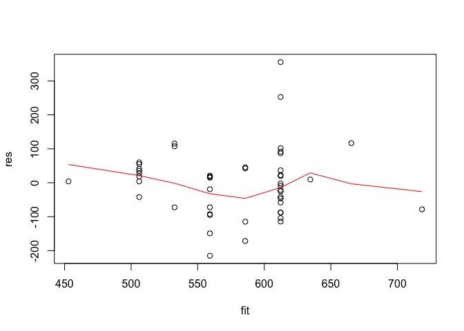

```r
fit<-m$fitted
res<-m$residuals
plot(fit,res)
lines(lowess(fit,res), col="red")
```

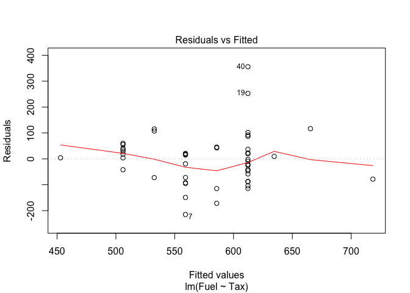

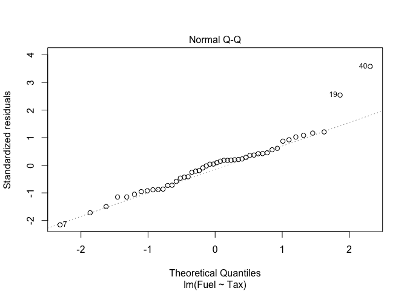

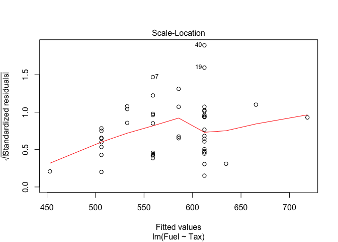

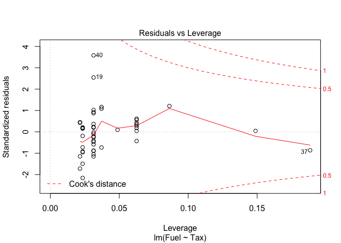

```r
plot(m)
```

You don’t want to see a pattern in the plot of residualsx fit.

Variation in Y = sum of squares of Y (SSY) = $\sum_{i-1}^n(Y_{i}-\bar Y )^2$

** ANOVA identity**

Variation in Y = Variation in $\hat Y$ + Variation in $Y-\bar Y$ = $\sum(Y_{i}-\bar Y)^2$ = $\sum (\hat Y_{i} - \bar Y)^2 + \sum(Y_{i}- \hat Y_{i})^2$

$\sum Y_{i}^2$ = $\sum \bar Y^2 +\sum(\hat Y_{i}-\bar Y)^2 + \sum(Y_{i}-\hat Y_{i})^2$ -> add the degree of freedom for the mean and the residuals. but this is pretty much never done.

```r
sum(res^2)
```

```
## [1] 468543.4
```

```r
sum((fit-mean(fit))^2)
```

```
## [1] 119823.1
```

```r
anova(m)
```

```
## Analysis of Variance Table
##
## Response: Fuel
##           Df Sum Sq Mean Sq F value   Pr(>F)
## Tax        1 119823  119823  11.764 0.001285 **
## Residuals 46 468543   10186
## ---
## Signif. codes:  0 '***' 0.001 '**' 0.01 '*' 0.05 '.' 0.1 ' ' 1
```

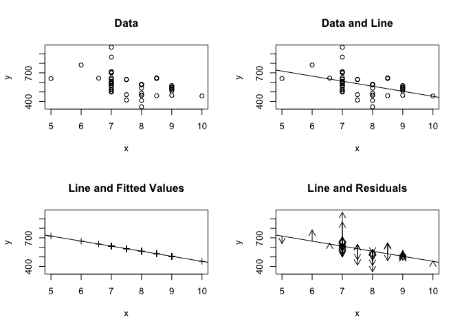

```r
arrowplot(Tax, Fuel)
```

Degrees of freedom: - start with n=48 degrees of freedom - 1 goes to the mean (only 47 numbers things to vary; because you can deduce the 48th count from the previous 47) - 1 for $\hat \beta$ (There are two linear restraints on the residuals, the mean=0 and ) - 46 left

ANOVA table trying to keep track of these degrees of freedom - how much is free to vary.

```r
## Proof of degrees of freedom being 1 for the mean
Fuel
```

```
##  [1] 541 524 561 414 410 457 344 467 464 498 580 471 525 508 566 635 603
## [18] 714 865 640 649 540 464 547 460 566 577 631 574 534 571 554 577 628
## [35] 487 644 640 704 648 968 587 699 632 591 782 510 610 524
```

```r
Fuel-mean(Fuel)
```

```
##  [1]  -35.7708333  -52.7708333  -15.7708333 -162.7708333 -166.7708333
##  [6] -119.7708333 -232.7708333 -109.7708333 -112.7708333  -78.7708333
## [11]    3.2291667 -105.7708333  -51.7708333  -68.7708333  -10.7708333
## [16]   58.2291667   26.2291667  137.2291667  288.2291667   63.2291667
## [21]   72.2291667  -36.7708333 -112.7708333  -29.7708333 -116.7708333
## [26]  -10.7708333    0.2291667   54.2291667   -2.7708333  -42.7708333
## [31]   -5.7708333  -22.7708333    0.2291667   51.2291667  -89.7708333
## [36]   67.2291667   63.2291667  127.2291667   71.2291667  391.2291667
## [41]   10.2291667  122.2291667   55.2291667   14.2291667  205.2291667
## [46]  -66.7708333   33.2291667  -52.7708333
```

```r
dif<-Fuel-mean(Fuel)
dif
```

```
##  [1]  -35.7708333  -52.7708333  -15.7708333 -162.7708333 -166.7708333
##  [6] -119.7708333 -232.7708333 -109.7708333 -112.7708333  -78.7708333
## [11]    3.2291667 -105.7708333  -51.7708333  -68.7708333  -10.7708333
## [16]   58.2291667   26.2291667  137.2291667  288.2291667   63.2291667
## [21]   72.2291667  -36.7708333 -112.7708333  -29.7708333 -116.7708333
## [26]  -10.7708333    0.2291667   54.2291667   -2.7708333  -42.7708333
## [31]   -5.7708333  -22.7708333    0.2291667   51.2291667  -89.7708333
## [36]   67.2291667   63.2291667  127.2291667   71.2291667  391.2291667
## [41]   10.2291667  122.2291667   55.2291667   14.2291667  205.2291667
## [46]  -66.7708333   33.2291667  -52.7708333
```

```r
sum(dif[1:47])
```

```
## [1] 52.77083
```

```r
mean(dif)
```

```
## [1] -3.789373e-14
```

```r
## Proof of degrees of freedom being 1 for the residuals

mean(res)
```

```
## [1] -5.190148e-15
```

```r
sum(res[1:47])
```

```
## [1] 88.26354
```

```r
res
```

```
##           1           2           3           4           5           6
##   34.949053   17.949053   54.949053 -171.710393 -149.157245    4.055351
##           7           8           9          10          11          12
## -215.157245  -92.157245  -95.157245 -114.263542   20.842755 -114.710393
##          13          14          15          16          17          18
##  -87.263542 -104.263542  -46.263542   22.736458   -9.263542  101.736458
##          19          20          21          22          23          24
##  252.736458  107.395904   36.736458  -19.157245  -42.050947   40.949053
##          25          26          27          28          29          30
##  -72.604096   59.949053   17.842755   45.289607   14.842755   27.949053
##          31          32          33          34          35          36
##  -41.263542  -58.263542   17.842755   42.289607  -72.157245    9.431812
##          37          38          39          40          41          42
##  -78.476138   91.736458  115.395904  355.736458  -25.263542   86.736458
##          43          44          45          46          47          48
##   19.736458  -21.263542  116.630160    3.949053   -2.263542  -88.263542
```

```r
lm(res~Tax)
```

```
##
## Call:
## lm(formula = res ~ Tax)
##
## Coefficients:
## (Intercept)          Tax
##   3.270e-15   -1.363e-15
```

```r
sum(res[1:47]*Tax[1:47])/Tax[48]
```

```
## [1] 88.26354
```

mean squares: Sum of squares divided by the degrees of freedom. mean squares of residual = $\sigma^2$ Fairer to compare mean squares than sum of squares

** F Value** signal to noise ratio. Expect it to be equal to 1 if it’s all noise. HIgher F value suggests a stronger, more clear signal.

P-Value, $H_{0}$:all $\beta$s are zero.

Now should know what each element of the ANOVA command stands for.

```r
anova(m)
```

```
## Analysis of Variance Table
##
## Response: Fuel
##           Df Sum Sq Mean Sq F value   Pr(>F)
## Tax        1 119823  119823  11.764 0.001285 **
## Residuals 46 468543   10186
## ---
## Signif. codes:  0 '***' 0.001 '**' 0.01 '*' 0.05 '.' 0.1 ' ' 1
```

```r
summary(m)
```

```
##
## Call:
## lm(formula = Fuel ~ Tax)
##
## Residuals:
##     Min      1Q  Median      3Q     Max
## -215.16  -72.27    6.74   41.28  355.74
##
## Coefficients:
##             Estimate Std. Error t value Pr(>|t|)
## (Intercept)   984.01     119.62   8.226 1.38e-10 ***
## Tax           -53.11      15.48  -3.430  0.00128 **
## ---
## Signif. codes:  0 '***' 0.001 '**' 0.01 '*' 0.05 '.' 0.1 ' ' 1
##
## Residual standard error: 100.9 on 46 degrees of freedom
## Multiple R-squared:  0.2037, Adjusted R-squared:  0.1863
## F-statistic: 11.76 on 1 and 46 DF,  p-value: 0.001285
```

```r
1-pf(11.764, 1, 46)
```

```
## [1] 0.001284796
```